# Descriptive statistics

Tutorial 3: exercises and solutions

Dr Massimiliano Canzi

## Setup

```r
library(tidyverse)
library(palmerpenguins)
```

## The data

We use the `penguins` data set from the lecture: 344 penguins, 3 species, 3 islands.

```r
glimpse(penguins)
```

```
Rows: 344
Columns: 8
$ species           <fct> Adelie, Adelie, Adelie, Adelie, Adelie, Ad…
$ island            <fct> Torgersen, Torgersen, Torgersen, Torgersen…
$ bill_length_mm    <dbl> 39.1, 39.5, 40.3, NA, 36.7, 39.3, 38.9, 39…
$ bill_depth_mm     <dbl> 18.7, 17.4, 18.0, NA, 19.3, 20.6, 17.8, 19…
$ flipper_length_mm <int> 181, 186, 195, NA, 193, 190, 181, 195, 193…
$ body_mass_g       <int> 3750, 3800, 3250, NA, 3450, 3650, 3625, 46…
$ sex               <fct> male, female, female, NA, female, male, fe…
$ year              <int> 2007, 2007, 2007, 2007, 2007, 2007, 2007, …
```

Some values are missing (`NA`). Keep that in mind: it matters for almost everything we do today.

# 1. Distributions

## 1.1 A normal distribution

`rnorm()` draws random numbers from a normal distribution. Draw 1000 values with a mean of 600 and a standard deviation of 80 (think of them as reaction times in ms), and save them into a tibble called `rt`.

Run `set.seed(1)` first, so that everyone gets the same random numbers.

```r
set.seed(1)
```

## 1.1 Solution

```r
rt <- tibble(value = rnorm(1000, mean = 600, sd = 80))
```

## 1.2 Plot it

Plot the distribution of `value` with `geom_density()`.

## 1.2 Solution

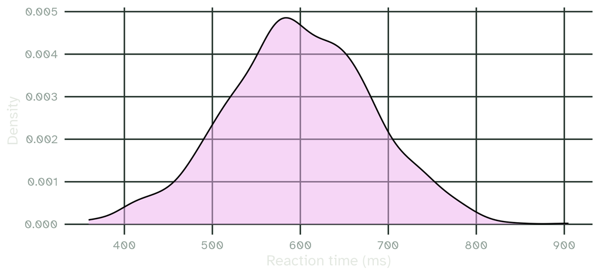

```r
rt |>
  ggplot(aes(x = value)) +
  geom_density(fill = "plum2", alpha = 0.5) +
  xlab("Reaction time (ms)") + ylab("Density")
```

## 1.3 Change the spread

Draw another 1000 values with the same mean but `sd = 20`, and plot both distributions together. What changes, and what stays the same? Start with `set.seed(2)`.

```r
set.seed(2)
```

## 1.3 Solution

```r
rt2 <- bind_rows(
  tibble(value = rnorm(1000, mean = 600, sd = 80), sd = "SD = 80"),
  tibble(value = rnorm(1000, mean = 600, sd = 20), sd = "SD = 20")
)
```

```r
rt2 |>
  ggplot(aes(x = value, fill = sd)) +
  geom_density(alpha = 0.5) +
  xlab("Reaction time (ms)") + ylab("Density")
```

## 1.3 Solution

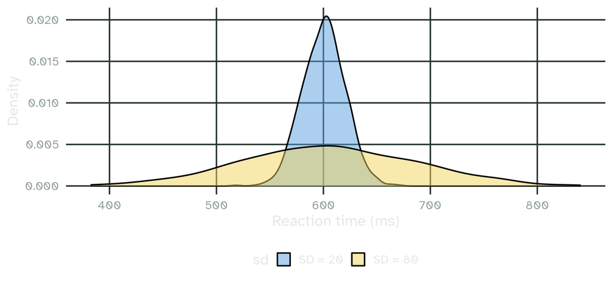

Both distributions are centred on 600 ms, and the one with the smaller SD is much narrower.

# 2. Central tendency

## 2.1 The mean

Compute the mean of `flipper_length_mm`. First try it directly: what happens?

## 2.1 Solution

```r
mean(penguins$flipper_length_mm)
```

```
[1] NA
```

`NA` means “unknown”, and the mean of numbers that include an unknown value is unknown too.

## 2.1 The mean

There are two ways around it. You can remove the rows with missing values with `na.omit()`, pull out the column and take its mean, or you can tell `mean()` to ignore the missing values with `na.rm = TRUE`. Try both.

## 2.1 Solution

```r
penguins |>
  na.omit() |>
  pull(flipper_length_mm) |>
  mean()
```

```
[1] 200.967
```

```r
mean(penguins$flipper_length_mm, na.rm = TRUE)
```

```
[1] 200.9152
```

## 2.1 The mean

The two numbers differ. Why? *Hint*: compare the number of rows.

## 2.1 Solution

```r
nrow(penguins)
```

```
[1] 344
```

```r
nrow(na.omit(penguins))
```

```
[1] 333
```

```r
sum(is.na(penguins$flipper_length_mm))
```

```
[1] 2
```

`na.omit()` removes every row with an `NA` in any column, including penguins whose flipper length we know but whose `sex` is missing. `na.rm = TRUE` only ignores the `NA`s in the column we are summarising.

## 2.2 The median

Compute the median of `flipper_length_mm`. Is it larger or smaller than the mean?

## 2.2 Solution

```r
median(penguins$flipper_length_mm, na.rm = TRUE)
```

```
[1] 197
```

The median (197 mm) is smaller than the mean (200.9 mm).

## 2.3 The mode

The mode is the most frequent value, and we use it with categorical data. Here is the function from the lecture:

```r
find_mode <- function(x) {
  u <- unique(x)
  tab <- tabulate(match(x, u))
  u[tab == max(tab)]
}
```

Which `island` do most penguins in the data come from? Which `species` is the most common?

## 2.3 Solution

```r
find_mode(penguins$island)
```

```
[1] Biscoe
Levels: Biscoe Dream Torgersen
```

```r
find_mode(penguins$species)
```

```
[1] Adelie
Levels: Adelie Chinstrap Gentoo
```

## 2.3 The mode

Check your answers with `count()`.

## 2.3 Solution

```r
penguins |> count(island)
```

```
# A tibble: 3 × 2
  island        n
  <fct>     <int>
1 Biscoe      168
2 Dream       124
3 Torgersen    52
```

```r
penguins |> count(species)
```

```
# A tibble: 3 × 2
  species       n
  <fct>     <int>
1 Adelie      152
2 Chinstrap    68
3 Gentoo      124
```

# 3. Spread

## 3.1 Standard deviation, MAD and range

For `body_mass_g`, compute the standard deviation, the median absolute deviation and the range.

## 3.1 Solution

```r
sd(penguins$body_mass_g, na.rm = TRUE)
```

```
[1] 801.9545
```

```r
mad(penguins$body_mass_g, na.rm = TRUE)
```

```
[1] 889.56
```

```r
range(penguins$body_mass_g, na.rm = TRUE)
```

```
[1] 2700 6300
```

## 3.1 Standard deviation, MAD and range

How many grams separate the lightest and the heaviest penguin?

## 3.1 Solution

```r
diff(range(penguins$body_mass_g, na.rm = TRUE))
```

```
[1] 3600
```

## 3.2 Quantiles

By default, `quantile()` gives the quartiles: the minimum, the 25%, 50% and 75% points, and the maximum. Compute them for `body_mass_g`. Which of these numbers is the median?

## 3.2 Solution

```r
quantile(penguins$body_mass_g, na.rm = TRUE)
```

```
  0%  25%  50%  75% 100%
2700 3550 4050 4750 6300
```

The 50% point is the median: half of the penguins weigh less than 4050 g.

## 3.3 Outliers

Here are 10 reaction times from one participant:

```r
rts <- c(512, 548, 575, 590, 601, 615, 630, 644, 668, 702)
```

Compute the mean, the median, the SD and the MAD. Then add one very slow trial of 3000 ms (the participant got distracted) and compute them again. Which measures change a lot, and which barely move?

## 3.3 Solution

```r
c(mean = mean(rts), median = median(rts), sd = sd(rts), mad = mad(rts))
```

```
     mean    median        sd       mad
608.50000 608.00000  56.31311  51.14970
```

```r
rts_slow <- c(rts, 3000)
c(mean = mean(rts_slow), median = median(rts_slow), sd = sd(rts_slow), mad = mad(rts_slow))
```

```
    mean   median       sd      mad
825.9091 615.0000 723.0407  59.3040
```

One slow trial pulls the mean and the SD up a lot, while the median and the MAD barely change: they are robust.

# 4. `group_by()` and `summarise()`

## 4.1 One group at a time

Compute the mean `body_mass_g` for each species, with `group_by()` and `summarise()`. Add the standard deviation and the number of penguins in each group, with `n()`.

## 4.1 Solution

```r
penguins |>
  group_by(species) |>
  summarise(mean_mass = mean(body_mass_g, na.rm = TRUE),
            sd_mass = sd(body_mass_g, na.rm = TRUE),
            n = n())
```

```
# A tibble: 3 × 4
  species   mean_mass sd_mass     n
  <fct>         <dbl>   <dbl> <int>
1 Adelie        3701.    459.   152
2 Chinstrap     3733.    384.    68
3 Gentoo        5076.    504.   124
```

## 4.2 The `.by` argument

Do the same with the `.by` argument instead of `group_by()`.

## 4.2 Solution

```r
penguins |>
  summarise(mean_mass = mean(body_mass_g, na.rm = TRUE),
            sd_mass = sd(body_mass_g, na.rm = TRUE),
            n = n(),
            .by = species)
```

```
# A tibble: 3 × 4
  species   mean_mass sd_mass     n
  <fct>         <dbl>   <dbl> <int>
1 Adelie        3701.    459.   152
2 Gentoo        5076.    504.   124
3 Chinstrap     3733.    384.    68
```

The numbers are the same, and the rows may come in a different order: `.by` keeps the groups in the order in which they first appear in the data.

## 4.3 Bonus

Which island has the heaviest penguins on average? Sort the result from heaviest to lightest with `arrange(desc())`.

## 4.3 Solution

```r
penguins |>
  summarise(mean_mass = mean(body_mass_g, na.rm = TRUE), .by = island) |>
  arrange(desc(mean_mass))
```

```
# A tibble: 3 × 2
  island    mean_mass
  <fct>         <dbl>
1 Biscoe        4716.
2 Dream         3713.
3 Torgersen     3706.
```

## 4.3 Bonus

Is this a fair comparison between islands? *Hint*: run `count(penguins, island, species)`.

## 4.3 Solution

```r
count(penguins, island, species)
```

```
# A tibble: 5 × 3
  island    species       n
  <fct>     <fct>     <int>
1 Biscoe    Adelie       44
2 Biscoe    Gentoo      124
3 Dream     Adelie       56
4 Dream     Chinstrap    68
5 Torgersen Adelie       52
```

Only Biscoe has Gentoo penguins, the heaviest species, so most of the difference between the islands comes from the species that live there.

## Reading

This tutorial goes with chapter 3 of Winter (2019).

Winter, B. (2019). *Statistics for linguists: An introduction using R*. Routledge. https://doi.org/10.4324/9781315165547

## Slides and exercises

[figure not shown]

These slides

mcanzi.de/statistics/tutorials/03_descriptive_statistics.html

Exercise sheet (R Markdown)

mcanzi.de/statistics/tutorials/03_descriptive_statistics.Rmd